# Patrick Miner

# About

I am a geographer with research and teaching on cities, mobilities, transport, and land use in the context of health, social justice, and climate change. I am based at the [University of Edinburgh](https://www.ed.ac.uk) in Geography in the School of GeoSciences with additional teaching in the Edinburgh Futures Institute. I am an [Associate Fellow of the Higher Education Academy (AFHEA)](https://advance-he.ac.uk/fellowship/). Methodologically, my work uses both quantitative (e.g. spatial analysis, statistics) and qualitative techniques (e.g. interviews, document analysis).

Prior to my current role in teaching and research, I completed PhD and MSc degrees also at the University of Edinburgh. My PhD research, completed in 2025, explored the repurposing of car-allocated land to improve multispecies health and wellbeing. The thesis challenged the car-based status quo through three lines of inquiry: it described the harm caused by the current system; it identified and measured the land allocated to cars; and it explored the potential of this land for improving health and wellbeing through the lens of the commons. My PhD research was funded by the Natural Environment Research Council (NERC) of UK Research and Innovation (UKRI) which is part of the UK government. The supervisory team was based at Edinburgh, Coventry University, UAL, and the University of Oxford.

Before moving into academia, I worked for 9 years in geography and urban planning in Chicago, USA. I worked at [IFF](https://www.iff.org), a non-profit planning organisation, and the [Chicago Architecture Center](https://www.architecture.org), a museum focusing on architecture and urban planning. I grew up in Michigan, USA and my undergraduate degree is in history and linguistics (with a minor in mathematics) from [Lawrence University](https://www.lawrence.edu).

# Publications

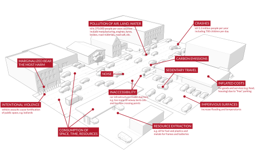

[Miner, Patrick, Barbara M. Smith, Anant Jani, Geraldine McNeill, and Alfred Gathorne-Hardy. 2024. **“Car harm: a global review of automobility’s harm to people and the environment”**. *Journal of Transport Geography*.](https://doi.org/10.1016/j.jtrangeo.2024.103817)

# Contact

Please contact me through one of the options below:

- [University of Edinburgh](https://edwebprofiles.ed.ac.uk/profile/patrick-miner)
- [LinkedIn](https://www.linkedin.com/in/patrickminer)
- [Bluesky](https://pdbminer.bsky.social)
- [Mastodon](https://mastodon.social/@pdbminer)

Research profiles:

- [ResearchGate](https://www.researchgate.net/profile/Patrick-Miner)
- [Google Scholar](https://scholar.google.com/citations?user=LiUyty0AAAAJ)
- [Scopus](https://www.scopus.com/authid/detail.uri?authorId=57472550400)
- [ORCID](https://orcid.org/0009-0002-2925-3258)

[figure not shown]

Photo of two front gardens. One is paved for parking and one is vegetated.

Copyright © 2021-2026 Patrick Miner.